# Extreme Dependence Model

Seoncheol Park

3/1/2020

여기 내용은 Dey and Yan (2015) 을 바탕으로 한다.

- $V$: exponent function
- $A$: Pickands dependence function, $V$의 변형
- $\theta$: extremal coefficient, $\theta = V(1,\ldots, 1)$, random vector $\mathbf{Y}$를 나타내는데 필요한 independent component들의 숫자, $\theta \in [1,d]$
- $R$: tail dependence function, counts the number of observations that fall in the failure region, i.e., all their coordinates are simultaneously large.
- $\chi$: coefficient of upper tail dependence, $\chi = R(1,\ldots, 1)$.

# Extreme Dependence Models

## Introduction

Statistical analyses of extreme events are of crucial importance for risk assessment in many areas such as the financial market, telecommunications, industry, environment, and health. For example, governments and insurance companies need to statistically quantify the frequency of natural disasters in order to plan risk management and take preventive actions.

Several examples of univariate anaysis are available, for instance in Coles (2011). Two main approaches are used in applications, the block-maximum and the peak over threshold. These are based on the generalized extreme value (GEV) distribution and the generalized Pareto distribution (GPD), which are milestones of the extreme value theory.

Many practical problems in finance, the environment, etc., are high dimensional by nature, for example when analyzing the air quality in an area, the amount of pollution depends on the levels of different pollutants and the interaction between them. Today, the extreme value theory provides a sufficiently mature framework for applications in the multivariate case. Indeed a large number of theoretical results and statistical methods an models are available.

In this article, we review some basic theoretical results on the extreme values of multivariate variables (multivariate extremes for brevity). With the block-maximum approach we explain what type of dependence structures can be described. We discuss the main features of some families of parametric extremal dependence models. By means of real data analysis we show the utility of these extremal dependence models when assessing the dependence of multivariate extremes. Their utility is also illustrated when estimating the probabilities that multivariate extreme events occur.

## Notations

- For $d\in \mathbb{N}$, let $I=\{1,\ldots, d\}$ be an index set
- $\mathbf{X}= (X_1, \ldots, X_d)$: $\mathbb{R}^{d}$-valued random vector with joint (probability distribution) $F$ and marginal distribution functions $F_{j}= F(\infty, \ldots, x_{j}, \ldots, \infty), j\in I$.
- $\mathbf{X}_1, \ldots, \mathbf{X}_{n}$: i.i.d. copies of $\mathbf{X}$
- $\mathbf{M}_{n} = (M_{n,1},\ldots, M_{n,d})$: sample vector of componentwise maxima, where $M_{n,j}=\max(X_{i,j},\ldots, X_{n,j})$

보통 $F$는 모른다고 가정하기 때문에 sample maxima의 distribution 또한 알지 못한다고 가정한다. 보통 이 상태에서 연구하는 방법은 $n\rightarrow\infty$일 때 $M_{n}$의 asymptotic distribution을 연구하는 것이다

## 리뷰: 다변량 EVD

- 다변량일 때의 $\mathbf{M}_{n}$의 asymptotic distirubtion은 univariate일 때와 비슷한다. 다음과 같이

$$\begin{equation}
P\Bigg( \frac{\mathbf{M}_{n}-\mathbf{b}_{n}}{\mathbf{a}_{n}}\leq \mathbf{x} \Bigg) = F^{n}(\mathbf{a}_{n}\mathbf{x} + \mathbf{b}_{n})\rightarrow G(\mathbf{x}), \qquad{n\rightarrow \infty,}
\tag{1}
\end{equation}$$

를 만족하는 $\mathbf{a}_n = (a_{n1},\ldots, a_{nd})$, $\mathbf{b}_{n} = (b_{n1}, \ldots, b_{nd})\in \mathbb{R}^{d}$가 존재한다고 가정하자. 이 때 식 (1) 의 class는 **multivariate extreme value distributions (MEVDs)**라고 부른다. 식 (1) 을 만족하는 분포함수 $F$는 **(maximum) domain of attraction of** $G$라고 한다.

MEVD의 attractive property는 **max-stability**로, 분포함수 $G$ on $\mathbb{R}^{d}$가 만약 모든 $n\in\mathbb{N}$에 대해 다음과 같은 sequences $\mathbf{a}_{n} > \mathbf{0}$, $\mathbf{b}_{n}\in\mathbb{R}^{d}$가 존재해

$$\begin{equation}
G(\mathbf{a}_{n}\mathbf{x} + \mathbf{b}_{n}) = G^{\frac{1}{n}}(\mathbf{x}),
\tag{2}
\end{equation}$$

이다. As a consequence, $G$ is such that $G^{a}$ is a distribution for every $a>0$. A class of distributions that satisfies such a property is named **max-infinitely divisible** (max-id). More precisely, a distribution $G$ on $\mathbb{R}^{d}$ is max-id, if for any $n \in \mathbb{N}$, there exists a distribution $F_{n}$ such that $G=F_{n}^{n}$. This means that $G$ can always be defined through the distribution of the sample maxima of $n$ i.i.d. random vectors.

MEVD의 class들을 characterize하기 위해 다음의 두 가지를 specify해야 한다.

- the form of the marginal dsitributions
- the form of the dependence structure

### The form of the marginal distributions

이건 간단한데, 만약 $F$가 수렴한다면, 모든 $j\in I$에 대해 marginal distributions $F_{j}$들 또한 수렴할 것이다. 모든 $j\in I$dp eogo $a_{jn}, b_{jn}$을 Laurens de Haan (2006) 의 Corollary 1.2.4 와 같이 설정한다. 이것은 $G$의 각각의 marginal distribution들이 GEV를 따름을 내포하는 것이다.

$$G(\infty, \ldots, x_{j}, \ldots, \infty) = \exp \Bigg[ - \Bigg\{ 1 + \xi_{j} \Bigg( \frac{x_{j}-\mu_{j}}{\sigma_{j}} \Bigg) \Bigg\}_{+}^{-\frac{1}{\xi_{j}}} \Bigg], \qquad{j\in I.}$$

이 때

- $(x)_{+} = \max(0, x)$
- $-\infty < \mu_{j}, \xi_{j} < \infty$, $\sigma_{j}>0$ ((Laurens de Haan 2006) 의 208-211쪽)

### The form of the dependence structure

여기서는 다시 세 단계로 나눌 수 있다.

- Marginal distribution이 다 같아지도록 $G$를 변환
- Standard distribution을 표현하기 위해 **Poisson point process (PPP)**를 사용
- Dependece form은 coordinate의 변화의 수단으로써 명시적으로 표현됨
1. $U_{j}(a) = F_{j}^{\leftarrow}(1-\frac{1}{a})$, $a>1$을 $F_{j} ,j\in I$의 **left-continuous inverse**라고 두자. 식 (1) 의 $a_{nj}, b_{nj}$이 모든 $y_{j} >0$에 대해,

$$\lim_{n\rightarrow\infty}\frac{U_{j}(ny_{j})-b_{n}}{a_{n}}=\frac{\sigma_{j}(y_{j}^{\xi_{j}}-1)}{\xi_{j}}+\mu_{j}, \qquad{j \in I,}$$

이고 따라서 $G_{0}$의 모든 continuity point들 $\mathbf{y} > \mathbf{0}$에 대해

$$\begin{align}
&\lim_{n\rightarrow\infty}F^{n}\{ U_{1}(ny_{1}),\ldots, U_{d}(ny_{d}) \}\\
&= G\Bigg( \frac{\sigma_{1}(y_{1}^{\xi_{1}}-1)}{\xi_{1}} + \mu_{1}, \ldots, \frac{\sigma_{d}(y_{d}^{\xi_{d}}-1)}{\xi_{d}} + \mu_{d} \Bigg) \equiv G_{0}(\mathbf{y})
\tag{3}
\end{align}$$

가 성립한다. ((Laurens de Haan 2006) Theorems 1.1.6, 6.1.1.)

이제 $0 < G_{0}(\mathbf{y}) < 1$을 만족하는 모든 $\mathbf{y}> \mathbf{0}$에 대해 식 (3) 의 양 변에 log를 취하고 $n\rightarrow \infty$일 때 $\log F\{ U_{1}(ny_{1}), \ldots, U_{d}(ny_{d}) \}$의 first-order Taylor expansion을 사용하면 다음 결과를 얻는다.

$$\begin{equation}
\lim_{n\rightarrow\infty} n [ 1- F\{ U_{1}(ny_{1}), \ldots, U_{d}(ny_{d}) \} ] = -\log G_{0}(\mathbf{y}) \equiv V(\mathbf{y}).
\tag{4}
\end{equation}$$

이 때 $V(\mathbf{y})$을 **exponent (dependence) function**이라고 부르며 multiple extreeme structure의 dependence (간단하게 **extremal dependence**)를 표현한다. 식 (4) 를 자세히 보면 $V$는 $F$의 functional form에 영향을 받음을 알 수 있다. 그런데 실제 상황에서는 $F$의 functional form이 알려져 있지 않다는 것이 문제가 된다.

이 때 가능한 방법은 $G_{0}$의 **max-infinitely divisible (max-id)** property를 이용하는 것이다. 모든 max-id 분포는 **Poisson points process (PPP)** 표현을 가능하게 해 준다. ((Falk, Hüsler, and Reiss 2010) 141-142쪽)

2. $N_{n}(\cdot)$을 다음과 같은 PPP로 정의한다.

$$N_{n}(\mathcal{A}):=\sum_{i=1}^{\infty}\mathbb{I}_{\{ \mathbf{P}_{i} \}}(\mathcal{A}), \mathbb{I}_{\{ \mathbf{P}_{i} \}}(\mathcal{A}) =
\begin{cases}
1, & \mathbf{P}_{i}\in \mathcal{A},\\
0, & \mathbf{P}_{i}\notin \mathcal{A}.
\end{cases}$$

이 때

- $\mathcal{A} \subset \mathbb{A}$ with $\mathbb{A}:= (0,\infty)\times \mathbb{R}_{+}^{d}$
- $\mathbf{P}_{i} = \Bigg[ \frac{i}{n}, \Bigg\{ 1 + \xi_{1} \Bigg( \frac{X_{i1}- b_{n1}}{a_{n1}} \Bigg) \Bigg\}^{\frac{1}{\xi_{1}}}, \ldots, \Bigg\{ 1 + \xi_{d} \Bigg( \frac{X_{id}- b_{nd}}{a_{nd}} \Bigg) \Bigg\}^{\frac{1}{\xi_{d}}} \Bigg], n\in\mathbb{N},$
- $\mathbf{X}_{i}, i=1,2,\ldots$: i.i.d. random vectors with distribution $F$이다.
- $\zeta \times \eta_{n}$: intensity measure, where $\zeta$ is the Lebesgue measure and for every $n\in \mathbb{N}$ and
- $\mathcal{B}_{\mathbf{y}}$: critical regions defined by $\mathcal{B}_{\mathbf{y}}:= \mathbb{R}_{+}^{d}\backslash [\mathbf{0}, \mathbf{y}]$ with $\mathbf{y}>0$,

$$\eta_{n}(\mathcal{B}_{\mathbf{y}}) = n[1-F\{ U_{1}(ny_{1}), \ldots, U_{d}(ny_{d}) \}]$$

is a finite measure.

만약 식 (3) 의 극한이 유효하다면, $N_{n}$은 $n\rightarrow\infty$임에 따라 $N$으로 converges weakly, 즉 intensity measure $\zeta \times \eta$인 PPP로 수렴한다. 이 때

$$\eta(\mathcal{B}_{\mathbf{y}}) = \eta \{ (\mathbf{v} \in \mathbb{R}_{+}^{d}: v_{1}>y \text{ or } \ldots \text{ or } v_{d}>y_{d}) \}\equiv V(\mathbf{y}), \qquad{\mathbf{y}>0}$$

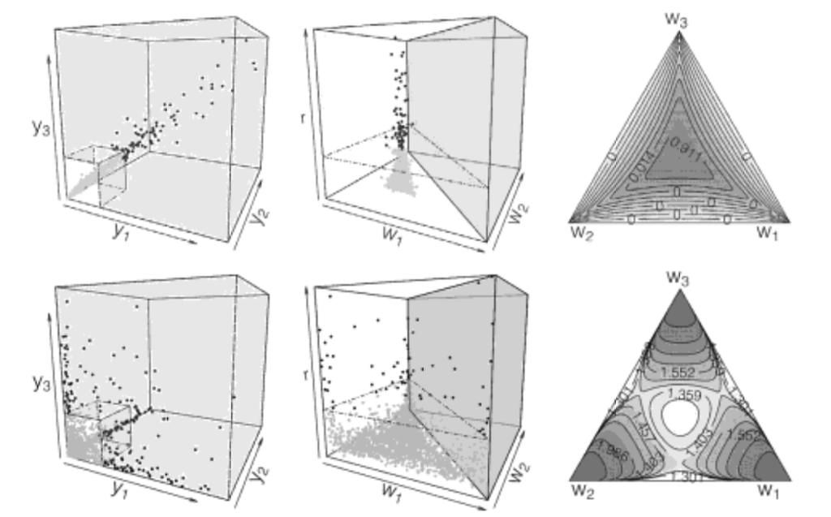

Figure 1: Examples of critical region in three-dimensional domain (left) and its representation in pseudopolar coordinates (middle). Black points are the extremes with strong (top-panels) and weak (bottom panels) dependence. (Right) Angular densities on the simplex.

이렇게 한다는 것은 critical region (그림 1 의 음영) numbering the rescaled observation이 들어가도록 한다는 것이다. 적어도 한 개의 coordinate가 클 경우 식 (3) 의 계산을 $N$의 void probability를 통해 계산이 가능케 한다는 것이다. 즉

$$\begin{align}
G_{0}(\mathbf{y}) &= P[N\{(0,1] \times \mathcal{B}_{\mathbf{y}} \} =0]\\
&= \exp ( -[\zeta \{ (0,1] \} \times \eta (\mathcal{B}_{y})])\\
&= \exp \{ - V(\mathbf{y}) \} \qquad{\mathbf{y}> \mathbf{0}.}
\tag{5}
\end{align}$$

그림 1 으로부터 strong dependence인 경우(왼쪽 위) 모든 coordinate에서 extreme 값이 커지게 되면, weak dependence인 경우(왼쪽 아래)에서는 오직 한 개의 coordinate에서만 extreme value 값이 큼을 알 수 있다.

이제 exponent measure의 구조를 특정지지을 차례다. 그런데 이것은 우리가 **pseudopolar coordinates**로 작업할 때 좀 더 단순해진다.

3. Unit Frechet margina에서 stability property (식 (2)) 는 $G_{0}^{a}(a\mathbf{y}) = G_{0}(\mathbf{y})$ (for any $a >0$) 로 다시 쓸 수 있다. 이것은 $\eta$가 다음과 같은 **homogeneity property**를 만족함을 의미한다.

$$\begin{equation}
\eta(a \mathcal{B}_{\mathbf{y}}) = \frac{\eta (\mathcal{B}_{\mathbf{y}})}{a},
\tag{6}
\end{equation}$$

for all $\mathcal{B}_{\mathbf{y}}\subset \bar{\mathbb{R}}$. 이 때

- $\mathcal{B}_{\mathbf{y}} := \bar{\mathbb{R}}\backslash (\mathbf{0}, \mathbf{y}]$ with $\mathbf{y} > \mathbf{0}$.

Note that for a Borel set $\mathcal{B} \subset \bar{\mathbb{R}}$에 대해 we have $a\mathcal{B} = \{ a\mathbf{v} : \mathbf{v} \in \mathcal{B} \}$ and $\mathcal{B}_{a\mathbf{y}} = a\mathcal{B}_{\mathbf{y}}$. 이제 다음과 같이 unit simplex on $\bar{\mathbb{R}}$인 $\mathbb{W}$를 정의해보자.

$$\mathbb{W}:= (\mathbf{v} \in \bar{\mathbb{R}}: v_1 + \ldots + v_{d} = 1).$$

이 때 $d-1$의 자유도를 갖는다. 임의의 $\mathbf{v} \in \mathbb{R}_{+}^{d}$에 대해 sub-norm $\| \mathbf{v} \| = |v_1| + \ldots + |v_d|$를 가지고 $\mathbf{0}$으로부터 $\mathbf{v}$까지의 거리를 잴 수 있다. (물론 다른 norm을 고려할 수도 있다.)

여기서 일대일 변환 $Q : \bar{\mathbb{R}}\rightarrow (0,\infty)\times \mathbb{W}$를 고러해보자.

$$(r,\mathbf{w}):= Q(\mathbf{v}) = (\| \mathbf{v} \| , \| \mathbf{v} \|^{-1}\mathbf{v} ), \qquad{\mathbf{v}\in \bar{\mathbb{R}}}.$$

이번엔 집합 $\mathcal{W}_{r} = r \times \mathcal{W}$ with $r>0$ and $\mathcal{W} \subset \mathbb{W}$에서 유도된 측도 $\phi : = \eta * Q$를

$$\psi (\mathcal{W}_{r}) = \eta \{ Q^{\leftarrow} (\mathcal{W}_{r}) \}$$

정의하자. 그러면 식 (6) 로 부터 다음을 얻는다.

$$\begin{align}
\psi(\mathcal{W}_{r}) &= \eta \{ (\mathbf{v} \in \bar{\mathbb{R}} : \|\mathbf{v} \|>r, \frac{\mathbf{v}}{\|\mathbf{v} \|} \in \mathcal{W} ) \}\\
&= \eta \{ (r\mathbf{u} \in \bar{\mathbb{R}} : \|\mathbf{u} \|>1, \frac{\mathbf{u}}{\|\mathbf{u} \|} \in \mathcal{W} ) \}\\
&= \frac{1}{r} H'(\mathcal{W}).
\end{align}$$

이 때

- $H'(\mathcal{W}):= \eta \{ (\mathbf{u}\in\bar{\mathbb{R}}: \| \mathbf{u} \| > 1, \frac{\mathbf{u}}{\| \mathbf{u} \|}\in \mathcal{W} ) \}$ 이다.

좌표를 이렇게 **pseudopolar**로 변환하는 것의 이점은 측도 $\eta$를 다음과 같이 두 개의 독립적인 측도의 곱으로 표현할 수 있다는 것이다.

- **radial measure** $(\frac{1}{r})$: intensity (or distance) of the points from the origin
- **spectral measure** or **angular measure** $(H')$: measures the angular spread (or direction) of the points (여기서는 angular measure라는 표현을 쓰기로 한다.)

이러한 결과는 **spectral decomposition**이라는 용어로 알려져 있다.

$\psi$의 density는 $\psi$를 미분하면 얻을 수 있을 것이고 다음과 같다.

$$d\psi (r, \mathbf{w}) = \frac{1}{r^2} dr \times dH'(\mathbf(w)), \qquad{\text{ for all } r>0 \text{ and } \mathbf{w} \in \mathbb{W}.}$$

이렇게 하면 $\eta(\mathcal{B}_{\mathbf{y}})$의 explicit form을 얻을 수 있는 것 같다.

$$\begin{align}
\eta(\mathcal{B}_{\mathbf{y}}) &= \psi \{ Q(\mathbf{w} \in \bar{\mathbb{R}} : v_{1} >y_{1} \text{ or } \ldots \text{ or } v_{d} > y_{d}) \}\\
&= \psi [ \{ (r,\mathbf{w}) \in (0, \infty) \times \mathbb{W} : r \min (\frac{y_{j}}{w_{j}}, j \in I) \} ]\\
&= \int_{\mathbb{W}}\int_{\min (\frac{y_{j}}{w_{j}}, j \in I)}^{\infty} \frac{1}{r^2}dr dH'(\mathbf{w})\\
&= \int_{\mathbb{W}}\max_{j\in I}(\frac{w_{j}}{v_{j}})dH'(\mathbf{w}).
\tag{7}
\end{align}$$

Pseudopolar coordinate를 사용하게 된다면, extreme을

- radial component는 high treshold보다 크고 (그림 1 의 가운데),
- angular component들은 (1) strong dependence인 경우에는 simplex의 중심에 모여있고 (그림 1 의 가운데-위) (2) weak dependence인 경우에는 simplex의 꼭짓점 부분에 모이게 된다. (그림 1 의 가운데-아래)

측도 $H'$는 $\mathbb{W}$에서 다음과 같은 first moment condition을 만족하는 어떤 finite measure이다.

$$\int_{\mathbb{W}}w_{j}dH'(\mathbf{w}) = 1, \qquad{\forall j \in I.}$$

이것은 $G_{0}$의 marginal distribution들이 unit Frechet임을 보장한다. 만약 $H'$가 first moment condition들을 만족한다면, total mass는 다음과 같다.

$$H'(\mathbb{W}) = \int_{\mathbb{W}} (w_1 + \ldots + w_d)dH'(\mathbf{w}) = \sum_{j \in I}\int_{\mathbb{W}} w_{j} dH'(\mathbf{w}) = d.$$

(아마 차원의 크기와 같아지는 듯)

따라서 $H = \frac{H'}{H'(\mathbb{W})}$로 놓음으로써 $H$는 확률측도가 되며 다음을 만족한다.

$$\begin{equation}
\int_{\mathbb{W}} w_{j}dH(\mathbf{w}) = \frac{1}{d}, \qquad{\forall j \in I.}
\tag{8}
\end{equation}$$

결론을 지으면 식 (3) , 식 (4) , 식 (5) 그리고 (7) 을 종합하여 MEVD with unit Frechet margins is equal to

$$\begin{equation}
G_{0}(\mathbf{y}) = \exp \Bigg\{ -d \int_{\mathbb{W}}\max_{j\in I}(\frac{w_{j}}{y_{j}}) dH(\mathbf{w}) \Bigg\} .
\tag{9}
\end{equation}$$

## Angular densities

측도 $H$는 simplex의 interior 뿐만 아니라 다른 부분집합, 예를 들면 edge나 vertexdpeh mass를 줄 수 있다. 따라서 $H$는 이러한 집합에 놓여있는 몇 가지 densities를 갖을 수 있고 이것을 **angular densities**라고 부른다. Coles and Tawn (1991) 는 $G$가 absolutely continuous일 때 angular density들을 유도하는 방법을 묘사하였다.

특별히, $\mathbb{S} := \mathbb{P}(I)\backslash \emptyset$으로 정의한다. 이 때 $\mathbb{P}(I)$는 power set이고 $\mathcal{S}$는 $\mathbb{S}$에서의 값들을 취하는 index set이다. 고정된 $d$가 주어졌을 때, 집합

$$\mathbb{W}_{d,\mathcal{S}} = ( \mathbf{w} \in \mathbb{W} : w_{j} = 0, \text{ if } j\neq \mathcal{S}; w_{j}>0 \text{ if } j \in \mathcal{S})$$

for all $\mathcal{S} \in \mathbb{S}$ provide a partition of $\mathbb{W}$ in $2^{d}-1$ subsets. Simplex의 경우와 마찬가지로 there are $k-1$ variables $w_{j}$ in $\mathbb{W}_{d,\mathcal{S}}$ that are free to vary, where $j \in \mathcal{S}$ and $k = |\mathcal{S}|$ denote the size of $\mathcal{S}$. We denote by $h_{d,\mathcal{S}}$ the density that lies on the subspace $\mathbb{W}_{d,\mathcal{S}}$, where $\mathcal{S}\in\mathbb{S}$. When the latter is a vertex $\mathbf{e}_{j}$ of the simplex $\mathbb{W}$, for any $j\in I$, then the density is a point mass, that is $h_{d,\mathcal{S}}=H(\{\mathbf{e}_{j} \})$.

Let $\mathcal{S}=\{i_{1},\ldots, i_{k}\}\subset I$, when $G_{0}$ is absolutely continuous the angular density for any $\mathbf{y}\in\mathbb{R}_{+}^{d}$ is

$$\begin{equation}
h_{d,\mathcal{S}} \Bigg( \frac{y_{i_{1}}}{\sum_{i\in\mathcal{S}}y_{i}}, \ldots, \frac{y_{i_{k-1}}}{\sum_{i\in\mathcal{S}}y_{i}} \Bigg)
= - \Bigg( \sum_{i\in\mathcal{S}}y_{i} \Bigg)^{(k+1)} \lim_{y_{j}\rightarrow 0, j\notin \mathcal{S}}\frac{\partial^{k}V}{\partial y_{i_{1}}\cdot \partial y_{i_{k}}}(\mathbf{y}).
\tag{10}
\end{equation}$$

그림 1 의 오른졲에서 3차원 angular density의 그림이 있다. 여기서는 strong (weak) dependence를 갖는 symmetric logistic model의 density들이다. When $\mathcal{S} = \{i \}$ for any $i\in I$, the angular density $h_{d,\mathcal{S}}$ represents the mass of $H$ at the vertex $\mathbf{e}_{j}$ with $j=i$, thus 식 (10) 는 다음과 같은 형태로 축소된다.

$$\begin{equation}
h_{d,\mathcal{S}} = H( \{ \mathbf{e}_{i} \}) = -y_{i}^{(2)}\lim_{y_{j}\rightarrow 0 , j \notin\mathcal{S}}\frac{\partial V}{\partial y_{i}}(\mathbf{y}).
\tag{11}
\end{equation}$$

이변량의 경우는 Pickands (1981) 가 얻은 결과와 동일해진다. $d=2$인 경우에 unit simplex $\mathbb{W}= [0,1]$는 다음과 같이 나누어 볼 수 있다.
$$\mathbb{W}_{2,\{1\}}=\{ (1,0) \}, \mathbb{W}_{2,\{2\}}=\{(0,1) \}, \mathbb{W}_{2,\{1,2\}}=\{ (w , 1-w), w\in (0,1) \}.$$

The densities that lie on them are

$$\begin{align}
h_{2,\{1\}} &= H(\{0\}) = -y_{1}^{2}\lim_{y_{2}\rightarrow 0}\frac{\partial V}{\partial y_{1}}(y_1, y_2)\\
h_{2,\{2\}} &= H(\{1\}) = -y_{2}^{2}\lim_{y_{1}\rightarrow 0}\frac{\partial V}{\partial y_{2}}(y_1, y_2)\\
h_{2,\{1,2\}}(w) &= -\frac{\partial^{2} V}{\partial y_{1} \partial y_{2}}(w, 1-w)
\end{align}$$

respectively for any $y_1, y_2>0$. 처음 두 density들은 extreme이 둘 중 한 변수에만 나타났을 경우이고 마지막 density는 두 변수 모두 extreme일 경우이다.

## Extremal dependence

식 (5) 으로부터 extremal dependence는 exponent function을 통해 표현될 수 있음을 안다. 이것은 $\mathbb{R}_{+}^{d}$에서 $(0,\infty)$로 가는 map이며 다음의 조건들을 만족한다.

1. continuous function and homogeneous of order $-1$, the latter meaning that $V(a\mathbf{y}) = \frac{1}{a}V(\mathbf{y})$ for all $a >0$.
2. convex function, that is $V(a\mathbf{y} + (1-a)\mathbf{y}') \leq aV(\mathbf{y}) + (a-1)V(\mathbf{y}')$, for $a\in [0,1]$ and $\mathbf{y}, \mathbf{y}' \in \mathbb{R}_{+}^{d}$.
3. $\max ( \frac{1}{y_1},\ldots, \frac{1}{y_d}) \leq V(\mathbf{y}) \leq (\frac{1}{y_1}+ \ldots + \frac{1}{y_d})$, 이 때 lower bound는 complete dependence, upper bound는 complete independence를 의미한다. ((Laurens de Haan 2006) 의 223-226쪽)

$\mathbf{Y}$를 분포 (9) 를 갖는 확률벡터라고 하자.

- 만약 $H$가 simplex의 center $(\frac{1}{d},\ldots, \frac{1}{d})$에서 total mass 1을 갖는다면 $Y_1 = Y_2 = \ldots = Y_d$ almost surely이다.
- 만약 $H$가 모든 $j\in I$의 $\mathbf{e}_{j}$에서 mass $\frac{1}{d}$를 갖는다면, 즉 vertex의 꼭짓점들에 잘 분배되어 있다면, $Y_1, \ldots, Y_d$은 indpendent이며 $G_{0}(\mathbf{y})=\exp (\frac{1}{y_1} + \ldots + \frac{1}{y_d})$이다.

이것은 분포 (1) 를 갖는 확률벡터 $\mathbf{X}$를 다음과 같이 쓸 수 있게 한다.

$$\min \{ G_{1}(x_1),\ldots, G_{d}(x_{d}) \} \leq G(\mathbf{x})\leq G_{1}(x_1)\cdot \ldots \cdot G_{d}(x_{d}), \qquad{\mathbf{x} \in \mathbb{R}^{d}.}$$

### Pickands dependence function

Exponent function을 좀 더 쉽게 시각화하기 위해 simplex에 restriction을 걸게 된다. 함수 $A:\mathbb{W} \rightarrow [\frac{1}{d}, 1]$은 **Pickands dependence function**이라고 하며 다음과 같다.

$$A(\mathbf{t}):= d\int_{\mathbb{W}}\max_{j\in I}(w_j t_j)dH(\mathbf{w}),$$

이 때 $z_{j} = \frac{1}{y_j}, j\in I, t_{j} = \frac{z_{j}}{z_{1} + \ldots + z_{d}}$ with $j=1, \ldots, d-1$ and $t_{d} = 1- (t_{1} + \ldots + t_{d-1})$ 이다. 당연히 $A$는 $V$의 성질을 물려받는다. 특별히

$$\frac{1}{d} \leq \max (t_1 , \ldots, t_d) \leq A(\mathbf{t}) \leq 1$$

이 되며 마찬가지로 lower bound는 complete dependence, upper bound는 complete independence를 나타낸다. 또한 $A$의 homogeneity property를 이용해 exponent function을 다음과 같이 쓸 수도 있다.

$$V(\mathbf{z}) = (z_1 + \ldots z_{d}) A(t_1, \ldots, t_d), \qquad{\mathbf{z} \in \mathbb{R}_{+}^{d}.}$$

### Extremal coefficient

Exponential function은 또한 여러가지 방법으로 사용될 수 있다. 우선, extremal dependence의 important summary는 다음과 같다.

$$\begin{equation}
\theta = V(1,\ldots, 1) = d\int_{\mathbb{W}}\max_{j\in I}(w_{j})dH(\mathbf{w}).
\end{equation}$$

이 $\theta$를 **extremal coefficient**라고 부른다. 이것은 random vector $\mathbf{Y}$를 나타내는데 필요한 independent component들의 숫자를 말해준다. $\theta$는 $H$가 simplex의 중심에 모여 있냐 (complete dependence, $\theta=1$), 또는 꼭짓점쪽으로 모이느냐에 따라 (complete independence, $\theta=d$)에 따라 값이 달라진다.

### Tail dependence function

이 때 **tail dependence function** $R(\mathbf{y})$를 다음과 같이 정의한다.

$$R(\mathbf{y}):=\eta \{ (\mathbf{v} \in \bar{\mathbb{R}}: v_{1} > y_{1}, \ldots, v_{d} > y_{d}) \}\equiv \eta(\mathcal{F}_{\mathbf{y}}), \qquad{\mathbf{y}>\mathbf{0}}.$$

$R(\mathbf{y})$는 counts the number of observations that fall in the failure region, i.e., all their coordinates are simultaneously large.

Tail dependence function은 exponent function과 inclusion-exclustion principle을 통한 관계가 있다. 식 (7) 및 식 (8) 에서 사용했던 것과 비슷한 논리를 사용한다면 다음의 결과를 얻는다.

$$\begin{equation}
R(\mathbf{y}) = d \int_{\mathbb{W}}\min_{j\in I}(\frac{w_{j}}{y_{j}})dH(\mathbf{w}), \qquad{\mathbf{y}> \mathbf{0}.}
\tag{12}
\end{equation}$$

### Coefficient of upper tail dependence

tail dependence function의 수단으로써, $\mathbf{Y}$의 component들의 상관관계를 정리하는 다른 방법으로 **coefficient of upper tail dependence** $\chi$가 있다.

$$\begin{equation}
\chi = R(1, \ldots, 1) = d\int_{\mathbb{W}}\min_{j\in I}(w_{j})dH(\mathbf{w}).
\end{equation}$$

이것은 $\mathbf{Y}$의 tail 파트의 dependence의 세기를 측정한다. 다시 말하면, $\mathbf{Y}$의 component들이 simultaneously large할 확률을 재는 것이다.

((Joe 1997) 의 bivariate version)

Joe (1997) 은 이변량 코퓰라 $C$에 대해 upper, lower tail dependence를 정의하였다.

참고로 $\lambda_{U}, \lambda_{L} \in [0,1]$이며 $\lambda_{U} =0, \lambda_{L}=0$이면 tail dependence가 없는 것이다.

$(U_{1}, U_{2})\sim C$였다고 하자. 그러면

$$\lambda_{U} = \lim_{u\rightarrow 1}P(U_{1}>u | U_{2}>u) =\lim_{u\rightarrow 1}P(U_{2} > u | U_{1} > u).$$

다시 원래 text로 돌아와서, $H$가 simplex의 center에 모여 있는 경우나 simplex의 변들에 모여있는 경우는 각각 $\chi>0, \chi=0$인 경우에 해당된다. 이런 경우를 각각 tail dependent, tail independent라고 부른다.

더 나아가, exponent와 tail dpenendece fucntion들은 특정한 타입의 extreme event가 일어날 확률을 근사하는 데 사용될 수 있다. $\mathbf{Y}$를 unit Pareto margin을 갖는 random vector라고 하자. $F$는 unit Frechet margin을 갖고 MEVD의 domain of attraction이라고 하자.

식 (4) 와 $V$의 homogeneity 성질에 의해 $n$이 클 때 $\{1-F(n\mathbf{y})\}\approx V(n\mathbf{y})$이다. 그러면 관계 (7) 와 (8) 에 의해 근사 결과는 다음과 같다.

$$\begin{equation}
P(Y_{1} > y_{1} \text{ or } \ldots \text{ or } Y_{d} > y_{d}) \approx d \int_{\mathbb{W}}\max_{j\in I}(\frac{w_{j}}{y_{j}}) dH(\mathbf{w}).
\end{equation}$$

이 때 $y_1, \ldots, y_{d}$는 충분히 큰 threshold들이다. 더 나아가, 다음과 같은 결과를 얻을 수도 있다.

$$\lim_{n\rightarrow \infty}n\bar{F}(ny_{1}, \ldots, ny_{d}) = R(\mathbf{y}).$$

이 때 $\bar{F}$는 $\mathbf{Y}$의 survivor function이다. $R$은 $V$와 같은 homogeneity property를 갖는다. 따라서 $n$이 클 때 $\bar{F}(n\mathbf{y})\approx R(n\mathbf{y})$이다. 따라서 관계 (12) 에 따라 근사 결과는 다음과 같게 된다.

$$\begin{equation}
P(Y_{1} > y_{1}, \ldots, Y_{d} > y_{d}) \approx d \int_{\mathbb{W}}\min_{j\in I}(\frac{w_{j}}{y_{j}})dH(\mathbf{w}),
\end{equation}$$

이 때 $y_1, \ldots, y_{d}$는 high enough threhold이다.

Lastly, when $\chi=0$, the elements of $\mathbf{Y}$ are independent in the limit. However, they may still be dependent for large but finite samples. Ledford (1996) proposed another dependence measure in order to capture this feature. 간결함을 위해 이변량 케이스에 초점을 맞춰보자. Suppose that $\bar{F}$ for $y\rightarrow \infty$ satisfies the condition

$$\bar{F}(y,y) \approx y^{-\frac{1}{\tau}}\mathcal{L}(y), \qquad{0< \tau \leq 1,}$$

where $\mathcal{L}$ is a **slowly function** 즉 $\frac{\mathcal{L}(ay)}{\mathcal{L}(y)}\rightarrow 1$ as $y\rightarrow \infty$ for any $a>0$. Then for large $y$, assuming $\mathcal{L}$ constant, different tail behaviors are covered.

- The case $\chi >0$ is reached when $\tau =1$ and so the variables are asymptotically dependent.
- When $\frac{1}{2}<\tau <1$, this means that $\chi = 0$ and so the variables are asymptotically independent, but they are still positively associated and the value of $\tau$ expresses the degree ((Ledford 1996)).

Coles, Stuart. 2011. *An Introduction to Statistical Modeling of Extreme Values*. Springer London. https://www.ebook.de/de/product/13423684/stuart_coles_an_introduction_to_statistical_modeling_of_extreme_values.html.

Coles, Stuart G., and Jonathan A. Tawn. 1991. “Modelling Extreme Multivariate Events.” *Journal of the Royal Statistical Society: Series B (Methodological)* 53 (2): 377–92. https://doi.org/10.1111/j.2517-6161.1991.tb01830.x.

Dey, Dipak K., and Jun Yan. 2015. *Extreme Value Modeling and Risk Analysis*. Taylor & Francis Inc. https://www.ebook.de/de/product/24179421/extreme_value_modeling_and_risk_analysis.html.

Falk, Michael, Jürg Hüsler, and Rolf-Dieter Reiss. 2010. *Laws of Small Numbers: Extremes and Rare Events*. Springer-Verlag GmbH. https://www.ebook.de/de/product/16204607/michael_falk_juerg_huesler_rolf_dieter_reiss_laws_of_small_numbers_extremes_and_rare_events.html.

Joe, Harry. 1997. *Multivariate Models and Multivariate Dependence Concepts*. Taylor & Francis Ltd. https://www.ebook.de/de/product/3675979/harry_university_of_british_columbia_vancouver_canada_joe_multivariate_models_and_multivariate_dependence_concepts.html.

Laurens de Haan, Ana Ferreira. 2006. *Extreme Value Theory*. Springer New York. https://www.ebook.de/de/product/5854909/ana_ferreira_laurens_de_haan_extreme_value_theory.html.

Ledford, A. 1996. “Statistics for Near Independence in Multivariate Extreme Values.” *Biometrika* 83 (1): 169–87. https://doi.org/10.1093/biomet/83.1.169.